# Análisis Predictivo - Grupo 1

Grupo 1

13/11/2019

### 0: Librerias Requeridas

```r
library(readxl)
library(dplyr)
library(tidyr)
library(cluster)
library(e1071)
library(mclust)
library(fpc)
library(NbClust)
library(factoextra)
library(ggplot2)
library(rpart)
library(caret)
library(rpart.plot)
library(randomForest)
library(e1071)
library(caret)
library(fastDummies)
library(rpart)
library(rpart.plot)
library(ggfortify)
library(corrplot)
library(forecast)
library(tseries)
library(stringr)
```

### 1: Lectura de Información

Para esta sección se utiliza la librería “readxl”.

```r
historia <- read_excel("Catálogo Guatemala 2018-2019.xlsx", sheet = 1,col_names=TRUE)
```

```
## * Pagina -> Pagina...7
## * Pagina -> Pagina...22
```

```r
Paginacion20152019 <- read_excel("Paginacion 2015-2019.xlsx", sheet = 1)
UnidadesPorSector <- read_excel("UnidadesPorSectorNew.xlsx", sheet = 1)
```

### 2: Limpieza y Preparación de Datos.

**Nota:** Es importante notar que se corrigio a mano el archivo de excel llamado:“Unidades por Sector”. Ver más en la guia de implementación.

Debido a que muchas veces la información solicitada no se encuentra de la forma ideal, se debe realizar un proceso de limpieza de datos donde se elimine y se corrija información de la data, estos pasos son los siguientes:

1. Renombramiento de columnas:

Al cargar la data, muchas veces R carga el nombre de columnas como algo totalmente diferente. Esto es por muchas razones, pero en este caso es porque las columnas tienen nombre no válidos para el lenguaje. En este paso, se buscan las columnas cuyos nombres fueron cambiados y se le colocan los nombres nuevos

```r
colnames(historia)
```

```
##  [1] "Año Mes"             "Producto"            "CONCA"
##  [4] "Codigo Catalogo"     "Descripcion"         "Categoria"
##  [7] "Pagina...7"          "Linea"               "Precio Catalogo"
## [10] "Precio Vta s/iva"    "Pronostico"          "Unidades Vendidas"
## [13] "Venta Neta s/iva"    "Costo"               "Utilidad"
## [16] "Margen"              "Pedido Real"         "Ratio"
## [19] "Observaciones"       "Canal de Venta"      "Contingencia"
## [22] "Pagina...22"         "Tipo Precio"         "%...24"
## [25] "Tipo Comision"       "%...26"              "Atributo Neto"
## [28] "Energy Chart"        "Promociones"         "Recursos Especiales"
## [31] "Treboles extra"
```

```r
names(historia)[names(historia) == "Pagina...7"] <- "Pagina"
names(historia)[names(historia) == "Pagina...22"] <- "Tipo.pagina"
names(historia)[names(historia) == "%..24"] <- "Porcentaje precio"
names(historia)[names(historia) == "%..26"] <- "Porcentaje comision"
names(historia)[names(historia) == "Tipo Precio"] <- "Tipo.Precio"
names(historia)[names(historia) == "Energy Chart"] <- "Energy Chart"
```

2. Estandarización a Mayúsculas

Esto se realiza para poder manejar correctamente la información, ya que facilita a la hora de manejar la información.

```r
historia <- data.frame(lapply(historia, function(v) {
  if (is.character(v)) return(toupper(v))
  else return(v)
}))

head(historia)
```

```
##   Año.Mes   Producto            CONCA Codigo.Catalogo
## 1  201801 4123660610 2018014123660610            1097
## 2  201801 4123660595 2018014123660595            1048
## 3  201801 4123660599 2018014123660599            1052
## 4  201801 4123660616 2018014123660616            1165
## 5  201801 4123761204 2018014123761204           11478
## 6  201801 4117270738 2018014117270738              73
##                               Descripcion              Categoria Pagina
## 1               DUO BETES CORPORAL Y PIES             USO DIARIO      1
## 2    TOP FAMILY CREMA BETES CORPORAL 370G      SALUD Y BIENESTAR      1
## 3         TOP FAMILY CREMA BETES PIES 90G      SALUD Y BIENESTAR      1
## 4                  TORINO FENOGRECO 100GR                  ELLAS     53
## 5 PAQUETE RECOMENDADO  GUATEMALA ENERO 18               PAQUETES      1
## 6                       MOCHILA PARA NIÑA PROMOCIONALES VENDIDOS     81
##              Linea Precio.Catalogo Precio.Vta.s.iva Pronostico
```

[output cut: 41 more lines]

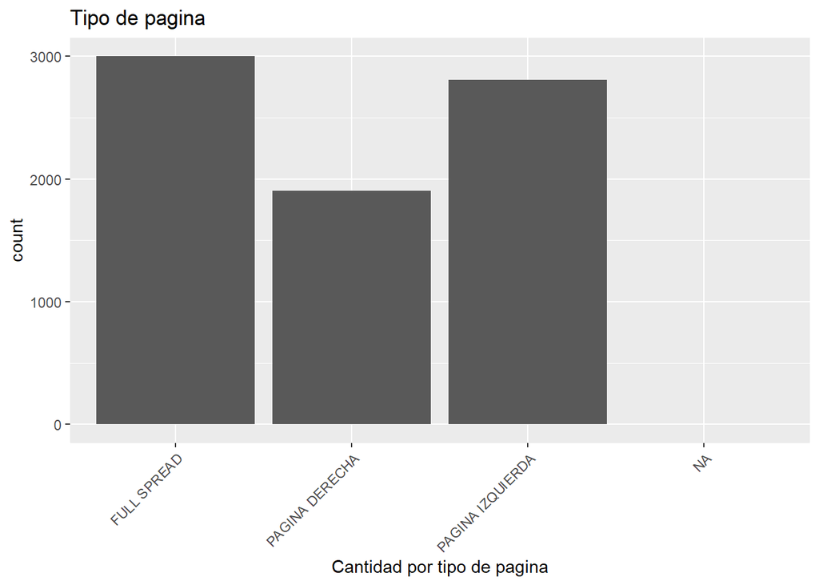

```r
clean_historia <- historia[1:31]
clean_historia <- data.frame(lapply(clean_historia, function(v) {
  if (is.character(v)) return(toupper(v))
  else return(v)
}))

ggplot(data = clean_historia)+
  xlab("Cantidad por tipo de pagina")+
  ggtitle("Tipo de pagina")+
  geom_bar(mapping = aes(x =Tipo.pagina))+ theme(axis.text.x = element_text(angle = 45, hjust = 1))
```

3. Eliminación y Correción de Caracteres Especiales

Esto se realiza porque pueden afectar en el momento de trabajar con la data, es posible que el lenguaje tenga problemas para leer o comprender correctamente ciertos carácteres especiales.

Primero separamos las colúmnas con carácteres especiales

```r
historia = separate(data =  historia,
                              col  =  Año.Mes,
                              into =  c("A?o", "Mes"),
                              sep  =  4, remove = TRUE,
                              convert = TRUE )

Paginacion20152019 = separate(data =  Paginacion20152019,
                              col  =  `Año Mes`,
                              into =  c("A?o", "Mes"),
                              sep  =  4, remove = TRUE,
                              convert = TRUE )
# separar producto y descripcion
UnidadesPorSector = separate(data =  UnidadesPorSector,
                              col  =  `Producto - Descripcion`,
                              into =  c("Producto", "Descripcion"),
                              sep  =  10, remove = TRUE,
                              convert = TRUE )
```

Luego, continuamos quitando las tildes y espacios innecesarios dentro de la información.

```r
# quitar tildes
historia$Descripcion <- chartr('??????','AEIOUN', historia$Descripcion)

Paginacion20152019$Descripcion <- chartr('??????','AEIOUN', Paginacion20152019$Descripcion)

Paginacion20152019 <- Paginacion20152019[complete.cases(Paginacion20152019$Pagina),]

#Quitar espacios al inicio y fin
Paginacion20152019$Pagina = gsub("^ ", "", Paginacion20152019$Pagina)
Paginacion20152019$Pagina = gsub(" $", "", Paginacion20152019$Pagina)
```

Por último, quitamos valores Nulos ya que son información poco relevante para el análisis.

```r
historia$Precio.Catalogo <- sub("NULL", NA, historia$Precio.Catalogo)
historia <- historia[complete.cases(historia$Precio.Catalogo),]

historia$Precio.Vta.s.iva <- sub("NULL", NA, historia$Precio.Vta.s.iva)
historia <- historia[complete.cases(historia$Precio.Vta.s.iva),]

historia$Costo <- sub("NULL", NA, historia$Costo)
historia <- historia[complete.cases(historia$Costo),]

head(sort(table(historia$Unidades.Vendidas) , decreasing = TRUE), n = 10)
```

```
##
##    0   48   76  109  167   49  159  166   53   92
## 1060   16   16   16   16   15   15   15   14   14
```

```r
Paginacion20152019$`Precio Catalogo` <- sub("NULL", NA, Paginacion20152019$`Precio Catalogo`)
Paginacion20152019 <- Paginacion20152019[complete.cases(Paginacion20152019$`Precio Catalogo`),]

Paginacion20152019$`Precio Vta s/iva` <- sub("NULL", NA, Paginacion20152019$`Precio Vta s/iva`)
Paginacion20152019 <- Paginacion20152019[complete.cases(Paginacion20152019$`Precio Vta s/iva`),]

Paginacion20152019$Costo <- sub("NULL", NA, Paginacion20152019$Costo)
Paginacion20152019 <- Paginacion20152019[complete.cases(Paginacion20152019$Costo),]
clean_historia[is.na(clean_historia$`Precio Catalogo`),] <- 0
```

### 3: Análisis Exploratorio

Se realiza un análisis exploratorio que permite entender de mejor la información. Ayuda a entender la distribución de la información, y encontrar puntos de interes útiles para el análisis. A continuación, se mostrarán los pasos tomados pero no se explicarán a profundidad el resultado, para esto leer el reporte final del proyecto.

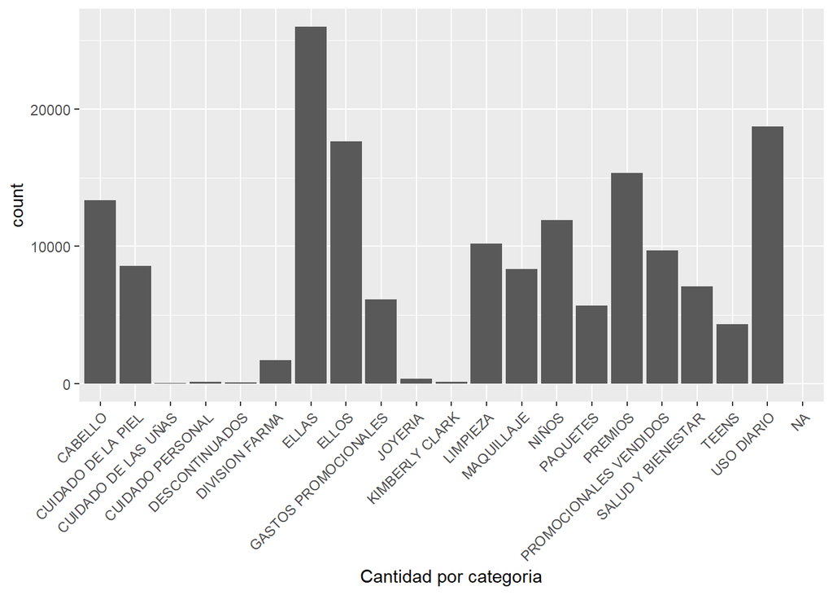

```r
ggplot(data = UnidadesPorSector)+
  xlab("Cantidad por categoria")+
  geom_bar(mapping = aes(x =DescripcionCategoria))+
  theme(axis.text.x = element_text(angle = 45, hjust = 1))
```

Seguimos con realizar un visualización de unidades por el sector de venta.

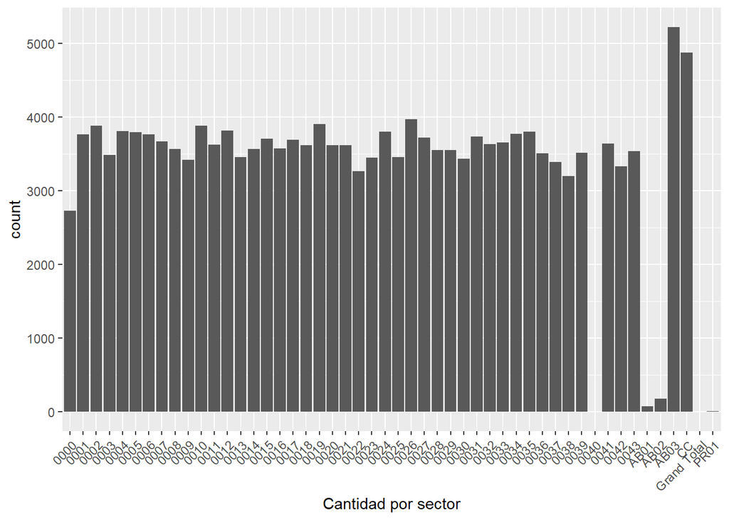

```r
ggplot(data = UnidadesPorSector)+
  xlab("Cantidad por sector")+
  geom_bar(mapping = aes(x =Sector))+ theme(axis.text.x = element_text(angle = 45, hjust = 1))
```

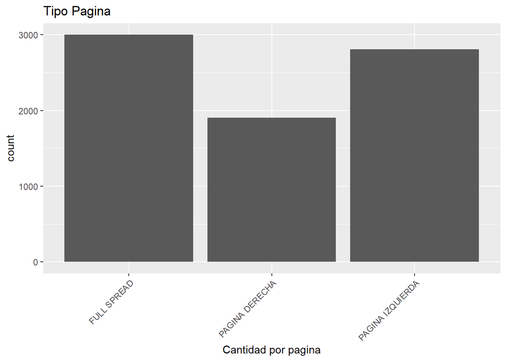

```r
  ggplot(data = clean_historia[!is.na(clean_historia$Tipo.pagina),])+
    xlab("Cantidad por pagina")+
    ggtitle("Tipo Pagina")+
    geom_bar(mapping = aes(x = Tipo.pagina))+ theme(axis.text.x = element_text(angle = 45, hjust = 1))
```

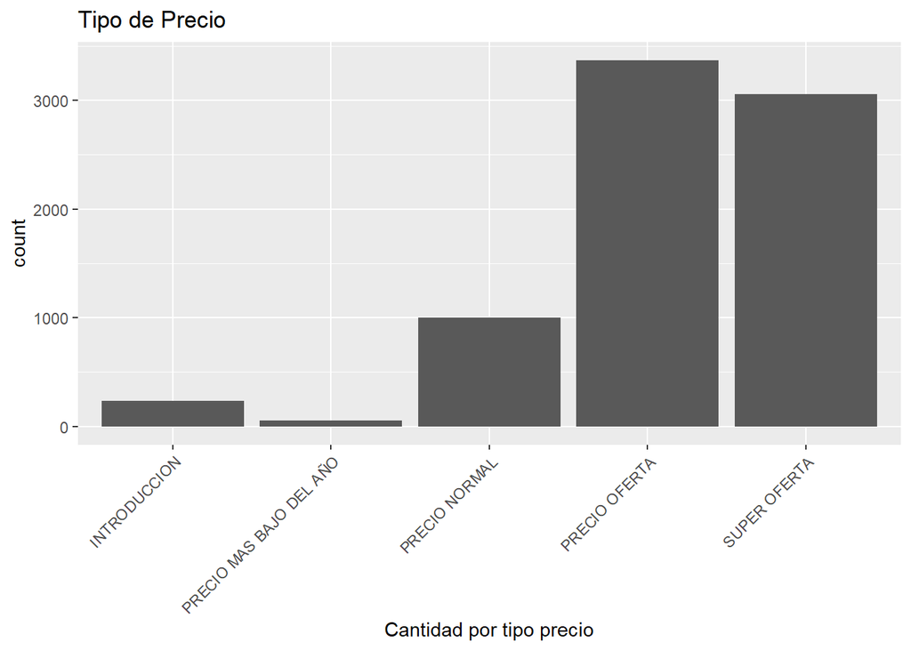

```r
ggplot(data = clean_historia[clean_historia$Tipo.Precio!="PRECIO NUNCA ANTES VISTO",])+
    xlab("Cantidad por tipo precio")+
    ggtitle("Tipo de Precio")+
    geom_bar(mapping = aes(x = Tipo.Precio))+ theme(axis.text.x = element_text(angle = 45, hjust = 1))
```

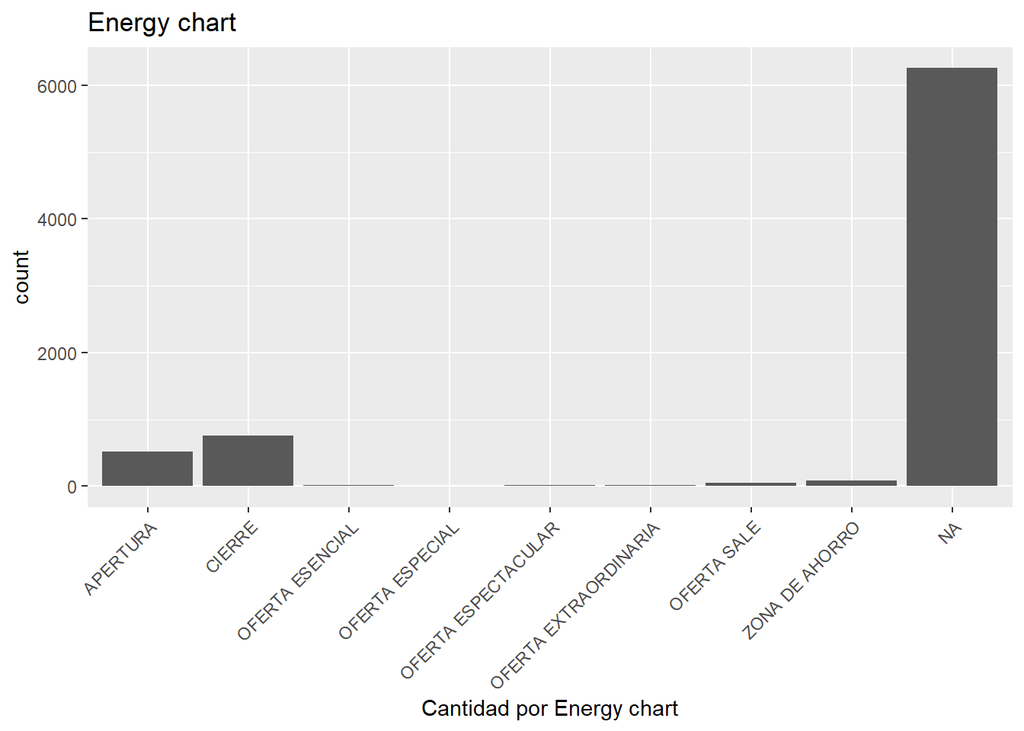

```r
ggplot(data = clean_historia)+
    xlab("Cantidad por Energy chart")+
    ggtitle("Energy chart")+
    geom_bar(mapping = aes(x = Energy.Chart))+ theme(axis.text.x = element_text(angle = 45, hjust = 1))
```

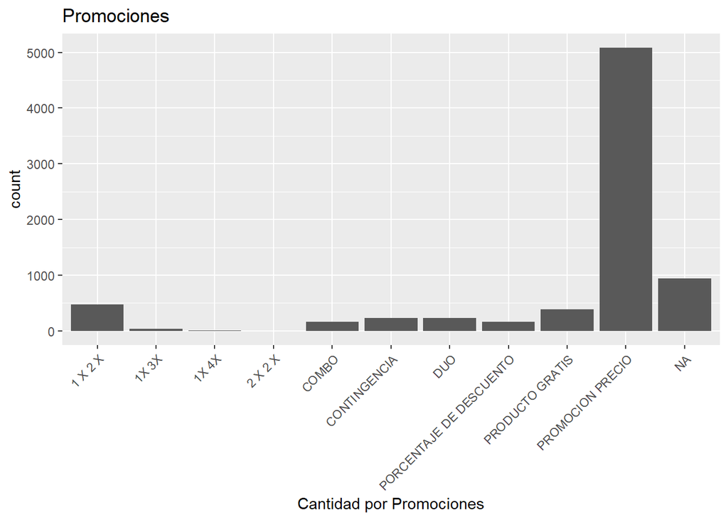

```r
  ggplot(data = clean_historia)+
    xlab("Cantidad por Promociones")+
    ggtitle("Promociones")+
    geom_bar(mapping = aes(x = Promociones))+ theme(axis.text.x = element_text(angle = 45, hjust = 1))
```

```r
checkformin_precio <- clean_historia[clean_historia$Precio.Catalogo !=0,]
names(checkformin_precio)
```

```
##  [1] "Año.Mes"             "Producto"            "CONCA"
##  [4] "Codigo.Catalogo"     "Descripcion"         "Categoria"
##  [7] "Pagina"              "Linea"               "Precio.Catalogo"
## [10] "Precio.Vta.s.iva"    "Pronostico"          "Unidades.Vendidas"
## [13] "Venta.Neta.s.iva"    "Costo"               "Utilidad"
## [16] "Margen"              "Pedido.Real"         "Ratio"
## [19] "Observaciones"       "Canal.de.Venta"      "Contingencia"
## [22] "Tipo.pagina"         "Tipo.Precio"         "X....24"
## [25] "Tipo.Comision"       "X....26"             "Atributo.Neto"
## [28] "Energy.Chart"        "Promociones"         "Recursos.Especiales"
## [31] "Treboles.extra"
```

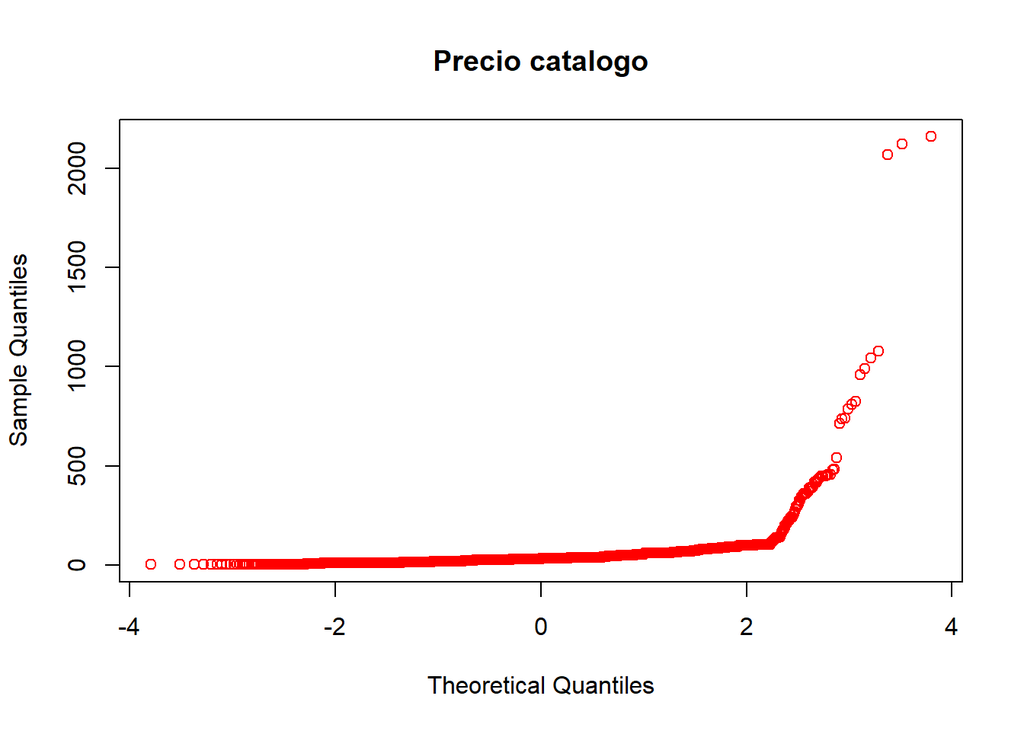

```r
qqnorm(checkformin_precio$Precio.Catalogo, main = "Precio catalogo", col = 2)
```

```r
clean_historia[is.na(clean_historia$`Precio Vta s/iva`),] <- 0
```